# Assignment 1

## Normalization

First, I distributed the data set I have got with normal distribution.

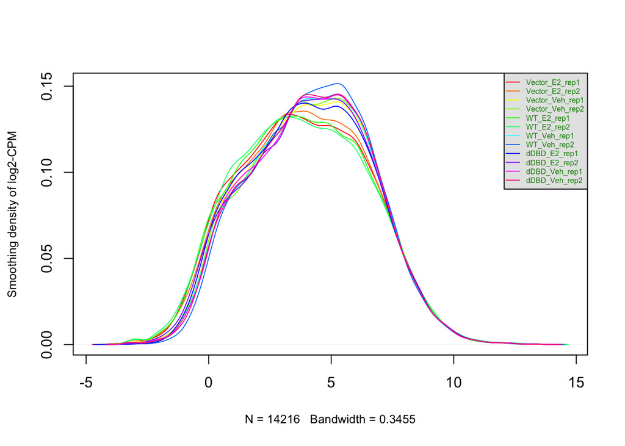

```r
library(edgeR)
data2plot <- log2(cpm(ER_exp_filtered[,2:13]))
counts_density <- apply(log2(cpm(ER_exp_filtered[,2:13])), 2, density)
xlim <- 0; ylim <- 0
for (i in 1:length(counts_density)) {
  xlim <- range(c(xlim, counts_density[[i]]$x));
  ylim <- range(c(ylim, counts_density[[i]]$y))
}
cols <- rainbow(length(counts_density))
ltys <- rep(1, length(counts_density))
plot(counts_density[[1]], xlim=xlim, ylim=ylim, type="n",
     ylab="Smoothing density of log2-CPM", main="", cex.lab = 0.8)
for (i in 1:length(counts_density)) lines(counts_density[[i]],col = cols[i])
legend("topright", colnames(data2plot),col=cols, lty=ltys, cex=0.5,
       border ="blue",  text.col = "green4",merge = TRUE, bg = "gray90")
```

This is the pre-normalization graph.I choose to use normal distribution, because since my data do not have have a huge differences, and to visualize the data more clearly, I choose Normal distribution. For boxplot, I have tried to use it, however, since the data a really close, eye-balling the difference is really difficult. Then, I used TMM Normalization, because it depends on samples.

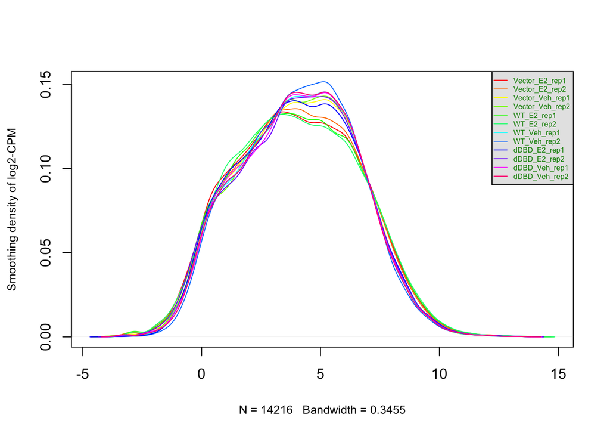

```r
filtered_data_matrix <- as.matrix(ER_exp_filtered[,2:13])
rownames(filtered_data_matrix) <- ER_exp_filtered[,1]
d = DGEList(counts=filtered_data_matrix, group=samples$cell_type)
d = calcNormFactors(d)
normalized_counts <- cpm(d)
counts_density <- apply(log2(normalized_counts), 2, density)
xlim <- 0; ylim <- 0
for (i in 1:length(counts_density)) {
  xlim <- range(c(xlim, counts_density[[i]]$x));
  ylim <- range(c(ylim, counts_density[[i]]$y))
}
cols <- rainbow(length(counts_density))
ltys <- rep(1, length(counts_density))
plot(counts_density[[1]], xlim=xlim, ylim=ylim, type="n",
     ylab="Smoothing density of log2-CPM", main="", cex.lab = 0.8)
for (i in 1:length(counts_density)) lines(counts_density[[i]],col = cols[i])
legend("topright", colnames(data2plot),col=cols, lty=ltys, cex=0.5,
       border ="blue",  text.col = "green4",merge = TRUE, bg = "gray90")
```

This is the distribution after normalizing the data.And to define the relation of the data sets, I have applied MD plots

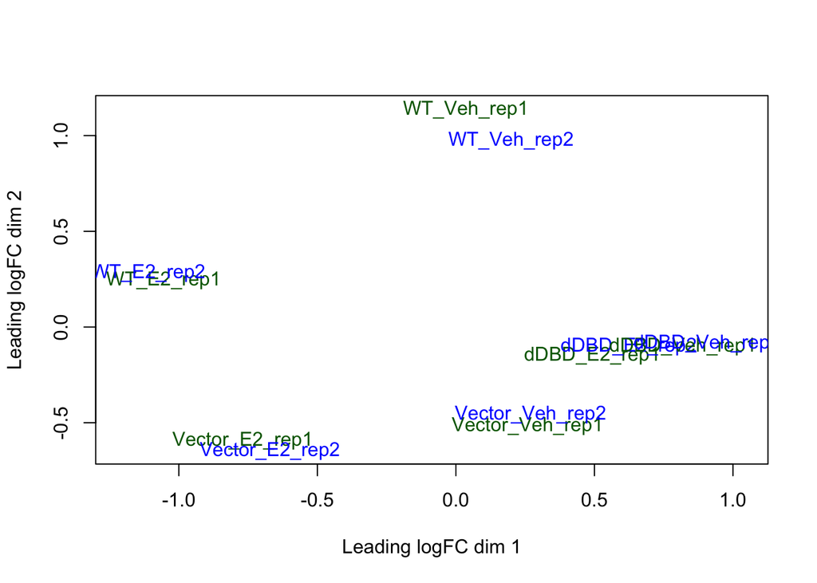

```r
plotMDS(d, labels = rownames(samples),col = c("darkgreen","blue")[factor(samples$cell_type)])
```

In the MD plot, the most of the replications have are similar in the graph, but some is not, and base on the article, the comparison is wild type, vector type and under vehicle condition.

Then I plotted the BCV graph for dispersion, and plotted mean-variance relation graph.

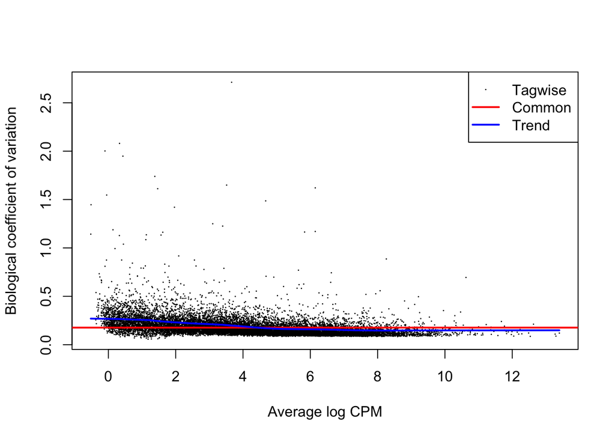

```r
model_design <- model.matrix(~samples$patients + samples$cell_type+0)
d <- estimateDisp(d, model_design)
plotBCV(d,col.tagwise = "black",col.common = "red",)
```

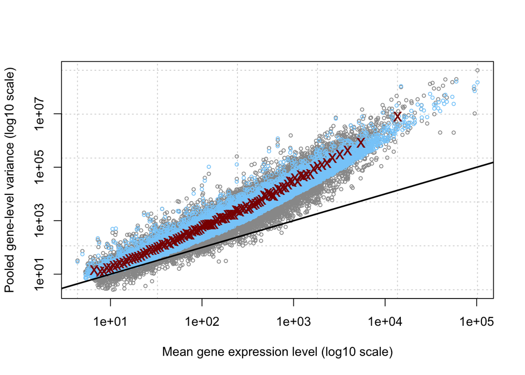

```r
plotMeanVar(d, show.raw.vars = TRUE, show.tagwise.vars=TRUE,
            show.ave.raw.vars = TRUE, NBline=FALSE,
            show.binned.common.disp.vars = FALSE)
```

## Citations

Mei,Y.,Ji H. L.,Zhao, Z.,Wenbo L.,Michael, G.et al.Enhancer RNAs Mediate Estrogen-Induced Decommissioning of Selective Enhancers by Recruiting ERα and Its Cofactor.The Author(s)(2020)https://www.cell.com/action/showPdf?pii=S2211-1247%2820%2930784-1